# MTH6139 Time Series

Coursework 1 – 220482747

Regina Liv Johansson

Spring term 2025

# Section 1: The Data

This project uses a data set of number of daily confirmed Covid19 cases per million citizens in Italy. The data starts in March of 2020 and ends February 23rd 2025. It was retired from https://ourworldindata.org/covid-cases. Upon importing the data, I converted it into a time series object in order to do some preliminary visualizations and analysis. The data is displayed as:

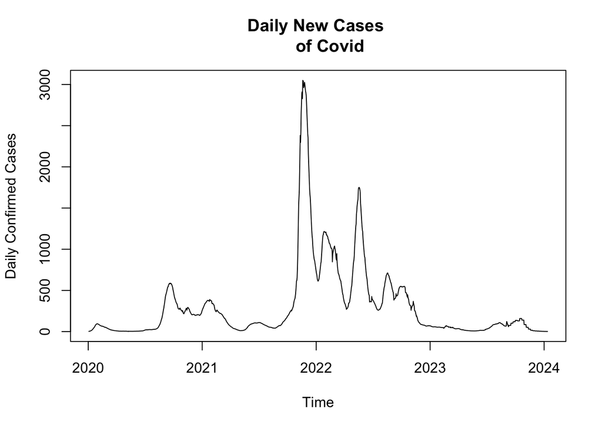

Please note that daily new cases are given per million people. This plot displays the spikes of Covid19 cases observed during the pandemic. The highest spike occured at the end of 2021 into the start of 2022. This spike is much larger than the initial spikes in 2020 when the disease first emerged, highlighting the increased spread but perhaps also increased testing. Post 2023 we see that the number of new infections drastically decreased, perhaps reflecting increased vaccination rates. Since then the pandemic is no longer classed as a threat and reporting may have slowed but we still see some spread even today, however, testing and reporting may not be as widespread so these numbers may underestimate true incidence of Covid19.

### Decomposition and Homoskedasticity

Next I decomposed the time series to better see its seasonality and trend.

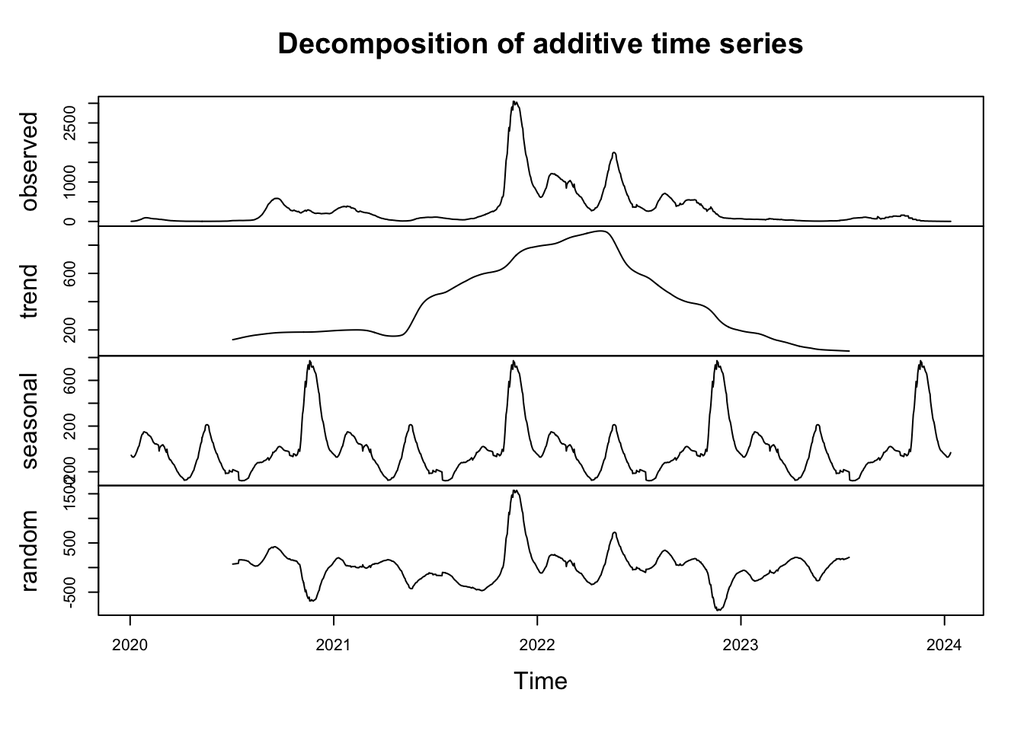

Here we see that there is no clear trend in the data. There is some seasonality with spikes occuring at the end into the beginning of each year. The random component looks fairly random but to be sure we don’t have any heteroskedasticity which may cause problems in the analysis, we perform a Breusch-Pagan test. The null hypothesis is “there is no heteroskedasticity”.

```
##
##  studentized Breusch-Pagan test
##
## data:  CasesTimeSeries ~ time(CasesTimeSeries)
## BP = 0.00042572, df = 1, p-value = 0.9835
```

As the p-value obtained is very large, we can conclude that there is indeed no issue with heteroskedasticity. Thus I will use the data as is, as there is no need for a Box-Cox transformation or similar.

# Section 2: Prophet Forecasting

### Initial Forecasting

Next, I will apply Meta’s Prophet forecasting system to the data to predict future cases of Covid19 in Italy. Within `prophet` I used “day” as frequency since the data was reported daily. Here I predict 8 periods into the future (next 8 days).

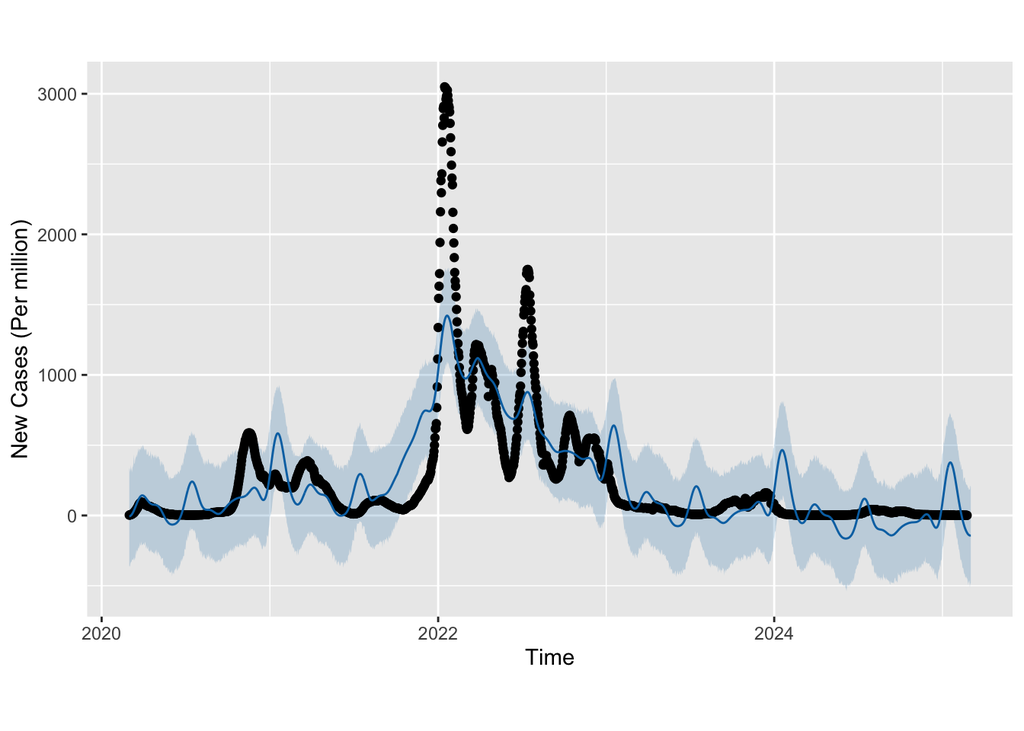

For better visualization I created an interactive graph:

[interactive chart not shown]

The interactive graph better shows the predicted versus the actual values. We see that in the largest spike the predictions severely underestimates the number of new cases. As we get past the worst time of the pandemic the predictions instead overestimate the number of cases in its spikes. Also, at certain points we are also given negative predictions. Thus this may not be the best method for predicting disease outbreak (at least for pandemic/epidemic purposes) as we cannot have negative incidence. However, by displaying the predicted value (yhat) and its upper and lower limits, we see that the upper limit is still positive:

```r
tail(predictions[c('ds', 'yhat', 'yhat_lower', 'yhat_upper')])
```

```
##              ds      yhat yhat_lower yhat_upper
## 1824 2025-02-26 -136.6875  -458.6397   199.3362
## 1825 2025-02-27 -139.3899  -481.0038   181.6036
## 1826 2025-02-28 -141.2777  -460.9479   187.5619
## 1827 2025-03-01 -142.3221  -511.2414   182.7964
## 1828 2025-03-02 -142.5159  -484.6887   211.5964
## 1829 2025-03-03 -142.4071  -481.9902   206.5428
```

Here we see that upper and lower limit deviate quite far from the predicted value. This represents the uncertainty in predicting future number of cases in this way. However, it may serve as a useful prognosis of worst case scenarios.

### Forecasting using Log

To avoid the problem of having negative predictions, I applied the same method of forecasting but on the log of the data. That is, I look the log value of the daily number of cases per million citizens as this would remove any negative values.

[interactive chart not shown]

Now we see that we have no negative predictions. Additionally, it seems like the predicted values more closely replicate the observed values when using the log of the data.

```r
tail(predictions2[c('ds', 'yhat', 'yhat_lower', 'yhat_upper')])
```

```
##              ds      yhat yhat_lower yhat_upper
## 1824 2025-02-26 0.6279936 -0.5799708   1.768643
## 1825 2025-02-27 0.6224680 -0.6221020   1.879243
## 1826 2025-02-28 0.6196167 -0.6964908   1.779535
## 1827 2025-03-01 0.6188383 -0.5170933   1.846568
## 1828 2025-03-02 0.6155853 -0.4996967   1.820675
## 1829 2025-03-03 0.6107207 -0.5949298   1.835416
```

Here we also see smaller intervals of the predicted values, indicating a better and more confident fit. However, the lower limits are negative.

### Changing Period Number

In the previous forecasts I used a forecasting period of 8, meaning 8 days into the future. While these values may be useful for understanding what may come in the immediate future and may help understand preparedness in the short term, it is not very helpful for the long run. So I ran the same predictions again using a period of 90, representing the next 3 months.

#### Original Data

[interactive chart not shown]

Here again the predictions are negative and do not seem very reliable.

#### Log Data

[interactive chart not shown]

Again using the log data seems to be a better fit. The longer term predictions seem to suggest that the number of new cases will continue to stay low with no spike within the coming 3 months. This seems consistent with the seasonality observed since spikes tend to occur in December/January.

Out of curiosity I also tried to extend the time period to cover the next year. I did this using the log data since this has returned the best predictions so far. This is what I obtained:

[interactive chart not shown]

It is impossible to say whether these predictions are accurate or not. One thing worth noting is that we do observe negative values in these predictions, implying they may not be very accurate, although we may be able to use a number closer to the upper limit, providing it is positive. It is also likely that in the future we will see random spikes of Covid19 during flu season, but this would require more refined techniques and subject specific knowledge to predict.

# Section 3: Holt Winters

Lastly, to compare different methods of predicting future cases I used Holt-Winters to see if I could smooth out the trend and predict some future values.

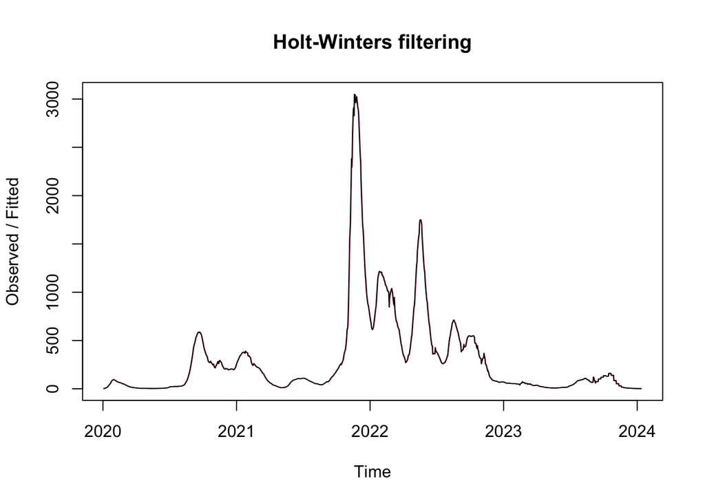

```r
HW <- HoltWinters(CasesTimeSeries, beta = FALSE, gamma = FALSE)
plot(HW)
lines(CasesPerMillion, col="red")
```

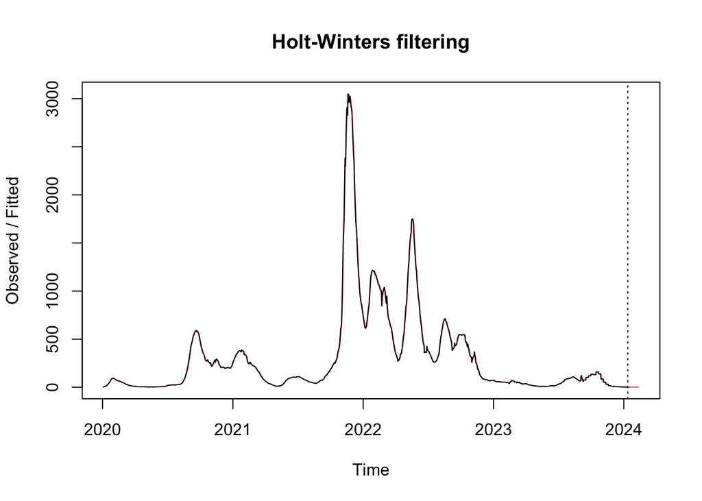

```r
predicted <- predict(HW, 30)
plot(HW, predicted)
```

I ran the prediction for the next 30 days. However, this method did not work well for predicting future cases as it returned a constant vector of predictions. This is not realistic because of the fluctuations observed and the nature of the data. I repeated the same analysis for the log data but obtained similar results so it will not be displayed.

# References

- RStudio reference: https://rmarkdown.rstudio.com/lesson-1.html
- Data source: Data retrieved from https://ourworldindata.org/covid-cases with reference to World Health Organization (2025) Population based on various sources (2024) (with major processing by Our World in Data)